# Data Visualization Assignment-II

### Group: DVI_GROUP006

Ponvani : 2018AC04559  
Venkataramanan Krishnan : 2018AC04529  
Poornima J : 2018AC04550  
Bala Kavin Pon : 2018AC04531

## Import dependencies

```python
import pandas as pd
import numpy as np
import seaborn as sns

import matplotlib.pyplot as plt
%matplotlib inline

# Using the seaborn plot styles
plt.style.use('seaborn')
```

### Question 01 [3 marks]

**A sample from the salaries data is provided in the file "ex01.txt".**

Plot and appropriate graph to help you derive an inference. You will have to explicitly state your inference what you have found.

Loading the data from `ex01.txt` file.

```python
cols = ["Salary","Experience"]

data_df = pd.read_csv("ex01.txt", names=cols, header=None);

data_df.info()
print("=="*40)
data_df.head()
```

```
<class 'pandas.core.frame.DataFrame'>
RangeIndex: 11 entries, 0 to 10
Data columns (total 2 columns):
Salary        11 non-null int64
Experience    11 non-null float64
dtypes: float64(1), int64(1)
memory usage: 304.0 bytes
================================================================================
```

|  | Salary | Experience |
| --- | --- | --- |
| 0 | 840000 | 8.7 |
| 1 | 380000 | 0.7 |
| 2 | 490000 | 1.7 |
| 3 | 880000 | 8.1 |
| 4 | 760000 | 6.0 |

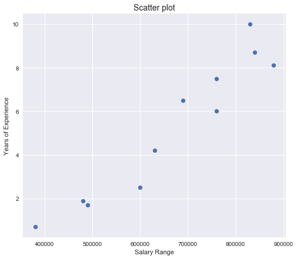

```python
plt.figure(figsize=(8,7))

plt.scatter(data_df.Salary, data_df.Experience)

plt.xlabel("Salary Range")
plt.ylabel("Years of Experience")
plt.title("Scatter plot", fontsize=14)

plt.show()
```

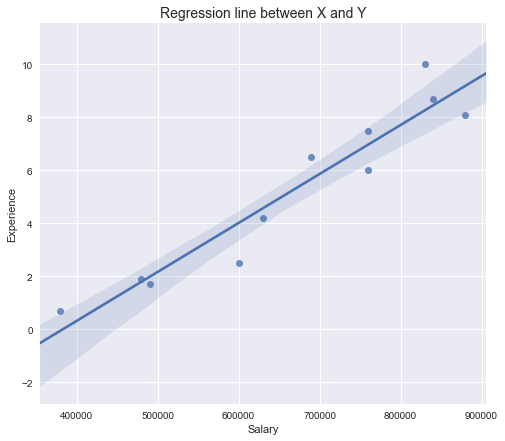

```python
f = plt.figure(figsize=(8, 7))
ax = f.gca()
sns.regplot(x="Salary", y="Experience", data=data_df, ax=ax); # Regression line plot
ax.set_title("Regression line between X and Y", fontsize=14)
plt.show()
```

### Inference:

```
From the given data and the above visualization, it is clear that the salary and the number of years of experience have a strong relation, as the years of experience increases, the salary also increases. We infer that the data attributes are positively related.
```

### Question 2 [3 marks]

**Analyze the GDP of the country from the data in the file "ex02.txt".**

Use the appropriate plot to help you derive an inference. You will have to explicitly state your inference what you have found.

Loading the data from `ex02.txt` file.

```python
cols = ['year', 'gdp']

ex2_df = pd.read_csv("ex02.txt", names=cols, header=None);

ex2_df.info()
print("=="*30)
ex2_df.head()
```

```
<class 'pandas.core.frame.DataFrame'>
RangeIndex: 9 entries, 0 to 8
Data columns (total 2 columns):
year    9 non-null int64
gdp     9 non-null float64
dtypes: float64(1), int64(1)
memory usage: 272.0 bytes
============================================================
```

|  | year | gdp |
| --- | --- | --- |
| 0 | 2011 | 8929.5 |
| 1 | 2012 | 8289.1 |
| 2 | 2013 | 10009.9 |
| 3 | 2014 | 11453.6 |
| 4 | 2015 | 13108.3 |

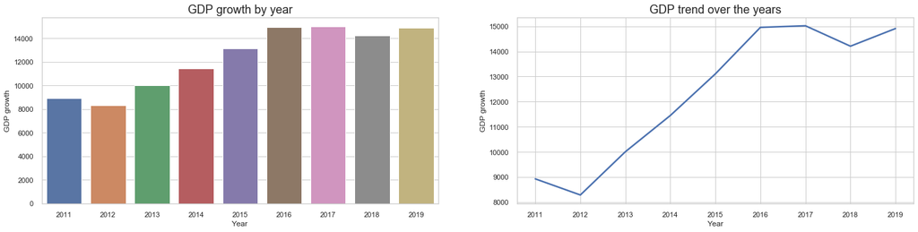

```python
fig, (ax1, ax2) = plt.subplots(1,2, figsize=(10,8))

# fig = plt.figure(figsize=(8,7))
# ax = fig.gca()
sns.barplot(x='year',y='gdp', data=ex2_df, ax=ax1)
sns.lineplot(x='year',y='gdp', data=ex2_df, linewidth=2.5, ax=ax2)
ax1.set_title("GDP growth by year", fontsize=18)
ax1.set_xlabel('Year', fontsize=12)
ax1.set_ylabel('GDP growth', fontsize=12)

ax2.set_xlabel('Year', fontsize=12)
ax2.set_ylabel('GDP growth', fontsize=12)
ax2.set_title("GDP trend over the years", fontsize=18)

plt.subplots_adjust(bottom=0.25, top=0.75, right=2.0)
plt.show()
```

### Inference:

```
The above plot depicts the GDP growth data against years from 2011 to 2019. The plot explains the following key points,
1. There was a decline in the GDP from 2011 to 2012.
2. The trend was changed and there was a steady increase in the GDP until 2016
3. Followed by a stationary momentum till 2017.
4. From 2017 to 2018 there was a decline in the line and again there was increase in the GDP.
```

### Question 3 [3 marks]

**The data of Oxygen and Carbon Levels of 2 cities over a period of time are given in the file "ex03.txt".**

Use the appropriate plot to help you derive an inference. You will have to explicitly state your inference what you have found.

```python
ex3_df = pd.read_csv("ex03.txt", header=0);

ex3_df.info()
print("=="*30)
ex3_df.head()
```

```
<class 'pandas.core.frame.DataFrame'>
RangeIndex: 10 entries, 0 to 9
Data columns (total 4 columns):
City    10 non-null object
Year    10 non-null int64
O2      10 non-null float64
CO2     10 non-null float64
dtypes: float64(2), int64(1), object(1)
memory usage: 448.0+ bytes
============================================================
```

|  | City | Year | O2 | CO2 |
| --- | --- | --- | --- | --- |
| 0 | delhi | 2011 | 24.2 | 0.04 |
| 1 | Bangalore | 2011 | 25.2 | 0.03 |
| 2 | delhi | 2013 | 25.3 | 0.05 |
| 3 | Bangalore | 2013 | 24.4 | 0.04 |
| 4 | delhi | 2015 | 26.1 | 0.06 |

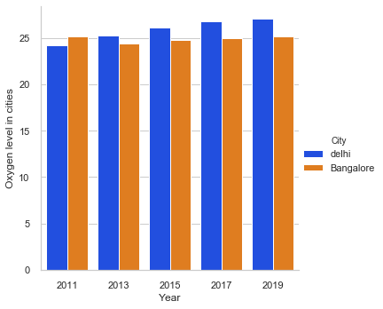

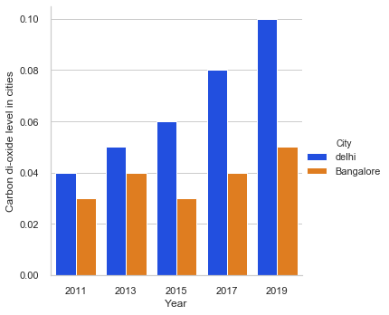

```python
ax1 = sns.catplot(x="Year", y="O2", hue="City", data=ex3_df, kind="bar", palette='bright')
ax1.set_ylabels("Oxygen level in cities")

ax2 = sns.catplot(x="Year", y="CO2", hue="City", data=ex3_df, kind="bar", palette="bright")
ax2.set_ylabels("Carbon di-oxide level in cities")

plt.show()
```

### Question 4 [3 marks]

The data of number of enrollments to various streams are shown for 2 successive years in the file **ex04.txt**.

Use the appropriate plot to help you derive an inference. You will have to explicitly state your inference what you have found and state the reason of the significance of the particular plot used.

Loading the data into a dataframe to analyze further.

```python
ex4_df = pd.read_csv("ex04.txt", header = 0)

ex4_df.columns=['Stream','Yr_2018','Yr_2019']
ex4_df.info()
print("=="*25)
ex4_df.head()
```

```
<class 'pandas.core.frame.DataFrame'>
RangeIndex: 4 entries, 0 to 3
Data columns (total 3 columns):
Stream     4 non-null object
Yr_2018    4 non-null int64
Yr_2019    4 non-null int64
dtypes: int64(2), object(1)
memory usage: 224.0+ bytes
==================================================
```

|  | Stream | Yr_2018 | Yr_2019 |
| --- | --- | --- | --- |
| 0 | Basic Sciences | 23764 | 17213 |
| 1 | Engineering | 66734 | 64398 |
| 2 | Arts | 18033 | 12383 |
| 3 | Commerce | 50876 | 63872 |

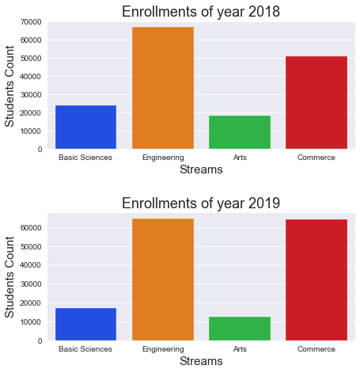

```python
fig, (ax1,ax2) = plt.subplots(2,1, figsize=(8,7))

sns.barplot(x="Stream", y="Yr_2018", data=ex4_df, ax=ax1, palette='bright')
sns.barplot(x="Stream", y="Yr_2019", data=ex4_df, ax=ax2, palette='bright')

ax1.set_xlabel("Streams", fontsize=15)
ax1.set_ylabel("Students Count", fontsize=15)
ax2.set_xlabel("Streams", fontsize=15)
ax2.set_ylabel("Students Count", fontsize=15)
ax1.set_title("Enrollments of year 2018", fontsize=18)
ax2.set_title("Enrollments of year 2019", fontsize=18)
# plt.legend()
plt.subplots_adjust(bottom=0.1, right=0.8, top=0.9, hspace=0.5)
plt.show()
```